# Adding user interface during play

Before we add timing and scoring to our `HitBeat`, we’ll add a score counter and improve the game’s look by adding a lovely background.

During play, the user interface has one of our custom labels at the top of the screen, and a metronome in the bottom left. The score will increase depending on how well the player taps the `HitBeat` in time to the song’s beat.

The metronome will pulse to the song’s beat to add a bit of energy to the scene.

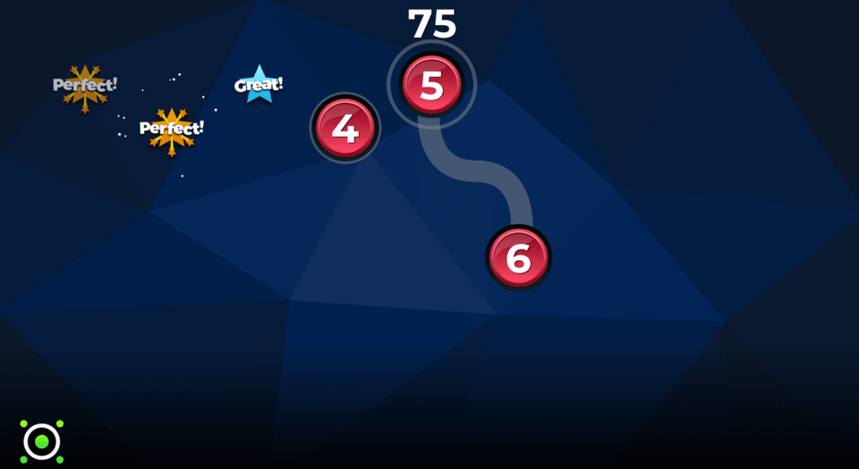

## Adding a background

First off, we’ll frame our play using a lovely background. I included an image for that in the start project, `background_shapes.png`. It matches the game resolution of 1920x1080 pixels.

Create a new `CanvasLayer` node in the *RhythmGameDemo* scene and rename it to *Background*. The *Layer* property determines what order `CanvasLayers` are drawn, so set it to something low such as `-20` to guarantee it’s always drawn below everything else.

Add a `Sprite` node and drag the `background_shapes.png` image to the *Texture* property. Uncheck the *Offset > Centered* property to have it fill the game’s viewport.

Your scene tree should look like this (I named my `Sprite` node *Shapes*).

[figure not shown]

And here are the sprite’s properties.

[figure not shown]

## Adding the play overlay

We’re going to add another `CanvasLayer`, which will house our user interface scenes.

Having the user interface on a separate drawing layer is generally good practice, especially in games where camera shake is present.

User interfaces should be easy to read, and having them separate from any camera movement helps with readability.

Add another `CanvasLayer` as a child of *RhythmGameDemo* and name it *UI*.

We’ll create two UI widgets as separate scenes, the score and metronome, and then add them to a third scene, `UITrackPlaying`.

## Creating the score scene

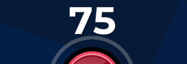

The score scene will reuse the `LabelCustom` scene we created earlier.

To update the text, we’ll need to communicate score changes across the project.

After all, this scene will be in the UI layer, and the score will come from interacting with the `HitBeats` or `HitRollers`. We’ll introduce a new signal to the `Events` autoload to accommodate for this interaction. Open up `Events.gd` and add the `scored` signal.

```
#...
# Emitted when the player made an action that increases the score.
signal scored(msg)
```

Now let’s create the scene. Create a new inherited scene by going to *Scene > New Inherited Scene…* and navigating to the `LabelCustom` scene. Rename the node as *UIScore* and save this scene in `res://RhythmGame/UI/TrackPlaying/UIScore.tscn`.

Having an inherited scene gives us more flexibility. For example, we could add a pulsating animation when the score increments by adding an `AnimationPlayer`.

Attach a new script to the node.

```
extends Label

# Keeps track of the current score as a number.
var _total_score := 0


func _ready() -> void:
    # We connect to our new signal to know when to increase the score.
    Events.connect("scored", self, "_add_score")


func _add_score(msg: Dictionary) -> void:
    # When the player scores, we increase the score and update the Label to show
    # it. You could play an animation here too.
    _total_score += msg.score
    text = str(_total_score)
```

## Creating the metronome scene

Next, we’ll create the metronome, a sprite that pulses along with the beat.

As we already have a signal that’s emitted every half-beat, we can design and code it right away.

Create a new scene with a `Sprite` as the root node. Name the node *UIMetronome* and save the scene as `res://RhythmGame/UI/TrackPlaying/UIMetronome.tscn`.

Add a `Tween` node as a child. We’ll use it to animate the image scaling up and down.

Assign the image `metronome_sprite.png` to the sprite’s *Texture* property.

Finally, attach a script to the sprite and define some properties.

```
extends Sprite

# To animate the sprite pulsating, we have it start at a large scale and scale
# up and down.
# The following properties define the animation's range.
var _start_scale := Vector2.ONE * 1.5
var _end_scale := Vector2.ONE

onready var _tween := $Tween


func _ready():
    # We connect to `beat_incremented` to trigger the animation every beat.
    Events.connect("beat_incremented", self, "_pulse")


func _pulse(msg: Dictionary):
    # We want to only pulse every beat (every two half-beats), so we return if
    # we're not on a beat.
    if msg.half_beat % 2 == 1:
        return

    var _beats_per_second: float = msg.bps
    # We animate the scale going down. This way, the metronome pops up every
    # beat and shrinks gradually, giving it some visual impact.
    _tween.interpolate_property(
        self,
        "scale",
        _start_scale,
        _end_scale,
        # We calculate a duration that makes the pulse faster in faster songs
        # songs, typically a fraction of a beat.
        _beats_per_second / 4,
        Tween.TRANS_LINEAR,
        Tween.EASE_OUT
    )
    _tween.start()
```

## Placing both the score and metronome on the screen

Let’s create the user interface to display during gameplay.

Create a new `User Interface` scene, rename the `Control` node as *UITrackPlaying*, and save it as `res://RhythmGame/UI/TrackPlaying/UITrackPlaying.tscn`.

Set the node’s *Mouse > Filter* to *Ignore*. This will prevent it from picking up any input events and getting in the way of tapping out `HitBeats`.

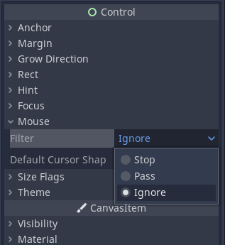

Add an instance of the `UIScore` scene.

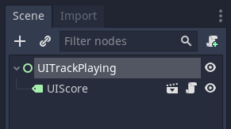

Then, align the score to the top of the viewport by clicking the *Layout* button and selecting *Top Wide*.

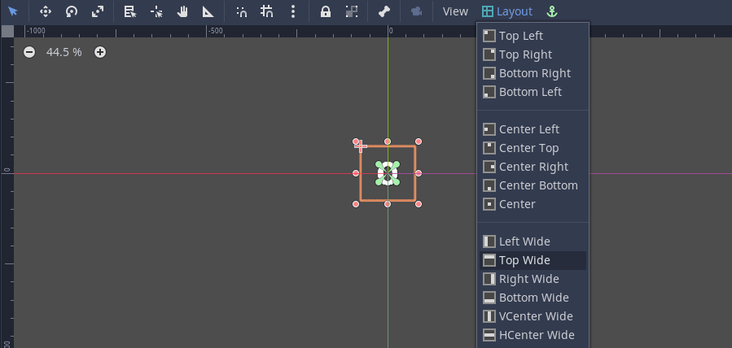

Instance the `UIMetronome` scene as a child of `UITrackPlaying` and position it where you like. I put it in the bottom left corner of the screen.

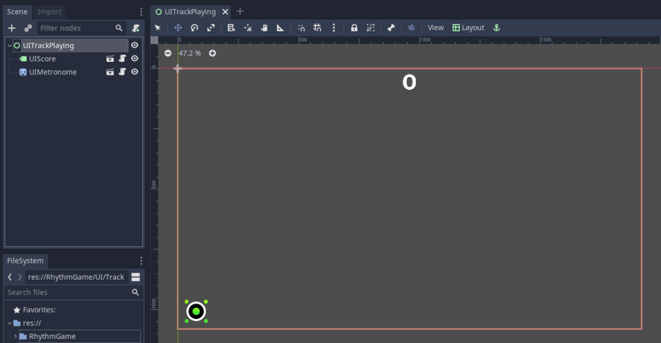

Finally, add the `UITrackPlaying` as a child to *UI* in *RhythmGameDemo*.

[figure not shown]

And there we have it! If you run the game, you’ll see the `HitBeats` spawn as before, but now with a shiny new metronome and score with them.

In the next lesson, we’ll delve back into the gameplay and add scoring and a timing mechanic to reward player skill when tapping in time to the beat.

## Final scripts

`UIScore.gd`

```
extends Label

var _total_score := 0


func _ready() -> void:
    Events.connect("scored", self, "_add_score")


func _add_score(msg: Dictionary) -> void:
    _total_score += msg.score
    text = str(_total_score)
```

`UIMetronome.gd`

```
extends Sprite

var _start_scale := Vector2.ONE * 1.5
var _end_scale := Vector2.ONE

onready var _tween := $Tween


func _ready():
    Events.connect("beat_incremented", self, "_pulse")


func _pulse(msg: Dictionary):
    if msg.half_beat % 2 == 1:
        return

    var _beats_per_second: float = msg.bps

    _tween.interpolate_property(
        self,
        "scale",
        _start_scale,
        _end_scale,
        _beats_per_second / 4,
        Tween.TRANS_LINEAR,
        Tween.EASE_OUT
    )
    _tween.start()
```

`Events.gd`

```
extends Node

signal beat_incremented(msg)
signal scored(msg)
```